# Data Preparation

### Importing Pandas library

```python
import pandas as pd
```

### Importing the 311 Customer Service Requests dataset

```python
request_data = pd.read_csv("Customer Service_Requests_from_2010_to_Present.csv", low_memory = False)
```

### Checking if the dataset is imported correctly

```python
request_data
```

|  | Unique Key | Created Date | Closed Date | Agency | Agency Name | Complaint Type | Descriptor | Location Type | Incident Zip | Incident Address | ... | Bridge Highway Name | Bridge Highway Direction | Road Ramp | Bridge Highway Segment | Garage Lot Name | Ferry Direction | Ferry Terminal Name | Latitude | Longitude | Location |
| --- | --- | --- | --- | --- | --- | --- | --- | --- | --- | --- | --- | --- | --- | --- | --- | --- | --- | --- | --- | --- | --- |
| 0 | 32310363 | 12/31/2015 11:59:45 PM | 01-01-16 0:55 | NYPD | New York City Police Department | Noise - Street/Sidewalk | Loud Music/Party | Street/Sidewalk | 10034.0 | 71 VERMILYEA AVENUE | ... | NaN | NaN | NaN | NaN | NaN | NaN | NaN | 40.865682 | -73.923501 | (40.86568153633767, -73.92350095571744) |
| 1 | 32309934 | 12/31/2015 11:59:44 PM | 01-01-16 1:26 | NYPD | New York City Police Department | Blocked Driveway | No Access | Street/Sidewalk | 11105.0 | 27-07 23 AVENUE | ... | NaN | NaN | NaN | NaN | NaN | NaN | NaN | 40.775945 | -73.915094 | (40.775945312321085, -73.91509393898605) |
| 2 | 32309159 | 12/31/2015 11:59:29 PM | 01-01-16 4:51 | NYPD | New York City Police Department | Blocked Driveway | No Access | Street/Sidewalk | 10458.0 | 2897 VALENTINE AVENUE | ... | NaN | NaN | NaN | NaN | NaN | NaN | NaN | 40.870325 | -73.888525 | (40.870324522111424, -73.88852464418646) |
| 3 | 32305098 | 12/31/2015 11:57:46 PM | 01-01-16 7:43 | NYPD | New York City Police Department | Illegal Parking | Commercial Overnight Parking | Street/Sidewalk | 10461.0 | 2940 BAISLEY AVENUE | ... | NaN | NaN | NaN | NaN | NaN | NaN | NaN | 40.835994 | -73.828379 | (40.83599404683083, -73.82837939584206) |
| 4 | 32306529 | 12/31/2015 11:56:58 PM | 01-01-16 3:24 | NYPD | New York City Police Department | Illegal Parking | Blocked Sidewalk | Street/Sidewalk | 11373.0 | 87-14 57 ROAD | ... | NaN | NaN | NaN | NaN | NaN | NaN | NaN | 40.733060 | -73.874170 | (40.733059618956815, -73.87416975810375) |
| ... | ... | ... | ... | ... | ... | ... | ... | ... | ... | ... | ... | ... | ... | ... | ... | ... | ... | ... | ... | ... | ... |
| 300693 | 30281872 | 03/29/2015 12:33:41 AM | NaN | NYPD | New York City Police Department | Noise - Commercial | Loud Music/Party | Club/Bar/Restaurant | NaN | CRESCENT AVENUE | ... | NaN | NaN | NaN | NaN | NaN | NaN | NaN | NaN | NaN | NaN |
| 300694 | 30281230 | 03/29/2015 12:33:28 AM | 03/29/2015 02:33:59 AM | NYPD | New York City Police Department | Blocked Driveway | Partial Access | Street/Sidewalk | 11418.0 | 100-17 87 AVENUE | ... | NaN | NaN | NaN | NaN | NaN | NaN | NaN | 40.694077 | -73.846087 | (40.69407728322387, -73.8460866160573) |
| 300695 | 30283424 | 03/29/2015 12:33:03 AM | 03/29/2015 03:40:20 AM | NYPD | New York City Police Department | Noise - Commercial | Loud Music/Party | Club/Bar/Restaurant | 11206.0 | 162 THROOP AVENUE | ... | NaN | NaN | NaN | NaN | NaN | NaN | NaN | 40.699590 | -73.944234 | (40.69959035300927, -73.94423377144169) |
| 300696 | 30280004 | 03/29/2015 12:33:02 AM | 03/29/2015 04:38:35 AM | NYPD | New York City Police Department | Noise - Commercial | Loud Music/Party | Club/Bar/Restaurant | 10461.0 | 3151 EAST TREMONT AVENUE | ... | NaN | NaN | NaN | NaN | NaN | NaN | NaN | 40.837708 | -73.834587 | (40.8377075854206, -73.83458731019586) |
| 300697 | 30281825 | 03/29/2015 12:33:01 AM | 03/29/2015 04:41:50 AM | NYPD | New York City Police Department | Noise - Commercial | Loud Music/Party | Store/Commercial | 10036.0 | 251 WEST 48 STREET | ... | NaN | NaN | NaN | NaN | NaN | NaN | NaN | 40.760583 | -73.985922 | (40.76058322950115, -73.98592204392392) |

300698 rows × 53 columns

### Dataset Insights

#### Number of rows and columns in the imported dataset

```python
print(f"The number of rows and columns in the dataset are, (rows, columns): {request_data.shape}")
```

```
The number of rows and columns in the dataset are, (rows, columns): (300698, 53)
```

#### Statistical Insights of the provided dataset carries

```python
request_data.describe()
```

|  | Unique Key | Incident Zip | X Coordinate (State Plane) | Y Coordinate (State Plane) | School or Citywide Complaint | Vehicle Type | Taxi Company Borough | Taxi Pick Up Location | Garage Lot Name | Latitude | Longitude |
| --- | --- | --- | --- | --- | --- | --- | --- | --- | --- | --- | --- |
| count | 3.006980e+05 | 298083.000000 | 2.971580e+05 | 297158.000000 | 0.0 | 0.0 | 0.0 | 0.0 | 0.0 | 297158.000000 | 297158.000000 |
| mean | 3.130054e+07 | 10848.888645 | 1.004854e+06 | 203754.534416 | NaN | NaN | NaN | NaN | NaN | 40.725885 | -73.925630 |
| std | 5.738547e+05 | 583.182081 | 2.175338e+04 | 29880.183529 | NaN | NaN | NaN | NaN | NaN | 0.082012 | 0.078454 |
| min | 3.027948e+07 | 83.000000 | 9.133570e+05 | 121219.000000 | NaN | NaN | NaN | NaN | NaN | 40.499135 | -74.254937 |
| 25% | 3.080118e+07 | 10310.000000 | 9.919752e+05 | 183343.000000 | NaN | NaN | NaN | NaN | NaN | 40.669796 | -73.972142 |
| 50% | 3.130436e+07 | 11208.000000 | 1.003158e+06 | 201110.500000 | NaN | NaN | NaN | NaN | NaN | 40.718661 | -73.931781 |
| 75% | 3.178446e+07 | 11238.000000 | 1.018372e+06 | 224125.250000 | NaN | NaN | NaN | NaN | NaN | 40.781840 | -73.876805 |
| max | 3.231065e+07 | 11697.000000 | 1.067173e+06 | 271876.000000 | NaN | NaN | NaN | NaN | NaN | 40.912869 | -73.700760 |

#### Major insights from the dataset

##### Dataset shape and size

```python
print(f"The total records in the imported dataset: {request_data.shape[0]}")
print(f"The total attributes/columns in the imported dataset: {request_data.shape[1]}")
print(f"The total number of the individual data in the dataset: {request_data.size}")
```

```
The total records in the imported dataset: 300698
The total attributes/columns in the imported dataset: 53
The total number of the individual data in the dataset: 15936994
```

##### Null value analysis

```python
print(f"The total number of null values in each columns of the dataset: ")
request_data.isnull().sum()
```

```
The total number of null values in each columns of the dataset:
```

```
Unique Key                             0
Created Date                           0
Closed Date                         2164
Agency                                 0
Agency Name                            0
Complaint Type                         0
Descriptor                          5914
Location Type                        131
Incident Zip                        2615
Incident Address                   44410
Street Name                        44410
Cross Street 1                     49279
Cross Street 2                     49779
Intersection Street 1             256840
Intersection Street 2             257336
Address Type                        2815
City                                2614
Landmark                          300349
Facility Type                       2171
Status                                 0
Due Date                               3
Resolution Description                 0
Resolution Action Updated Date      2187
Community Board                        0
Borough                                0
X Coordinate (State Plane)          3540
Y Coordinate (State Plane)          3540
Park Facility Name                     0
Park Borough                           0
School Name                            0
School Number                          0
School Region                          1
School Code                            1
School Phone Number                    0
School Address                         0
School City                            0
School State                           0
School Zip                             1
School Not Found                       0
School or Citywide Complaint      300698
Vehicle Type                      300698
Taxi Company Borough              300698
Taxi Pick Up Location             300698
Bridge Highway Name               300455
Bridge Highway Direction          300455
Road Ramp                         300485
Bridge Highway Segment            300485
Garage Lot Name                   300698
Ferry Direction                   300697
Ferry Terminal Name               300696
Latitude                            3540
Longitude                           3540
Location                            3540
dtype: int64
```

##### Duplicate records in the dataset

```python
request_data.duplicated().sum()
```

```
0
```

### Converting the datatype of columns: 'Created Date' and 'Closed Date' to DateTime

```python
request_data['Created Date'] = pd.to_datetime(request_data['Created Date'], errors='coerce')
request_data['Closed Date'] = pd.to_datetime(request_data['Closed Date'], errors='coerce')
```

### Checking if columns are datetime (dtype will be datetime64[ns] for DateTime)

```python
request_data[['Created Date', 'Closed Date']].dtypes
```

```
Created Date    datetime64[ns]
Closed Date     datetime64[ns]
dtype: object
```

### Creating a new column 'Request_Closing_Time' as the time difference between 'Created Date' and 'Closed Date'

```python
request_data['Request_Closing_Time'] = request_data['Closed Date'] - request_data['Created Date']
```

```python
request_data['Request_Closing_Time']
```

```
0        0 days 00:55:15
1        0 days 01:26:16
2        0 days 04:51:31
3        0 days 07:45:14
4        0 days 03:27:02
               ...
300693               NaT
300694   0 days 02:00:31
300695   0 days 03:07:17
300696   0 days 04:05:33
300697   0 days 04:08:49
Name: Request_Closing_Time, Length: 300698, dtype: timedelta64[ns]
```

### Droping the irrelevant table columns from the dataset (inplace = True for permanently changing in the dataset)

##### Columns before dropping the irrelevant columns

```python
print(request_data.columns.tolist())
```

[output not shown]

```python
print(f"The number of columns before dropping the irrelevant columns: {request_data.shape[1]}")
```

```
The number of columns before dropping the irrelevant columns: 54
```

##### Dropping the irrelevent columns

```python
irelevant_table_columns = ['Agency Name','Incident Address','Street Name','Cross Street 1','Cross Street 2','Intersection Street 1',
                           'Intersection Street 2','Address Type','Park Facility Name','Park Borough','School Name', 'School Number','School Region',
                           'School Code','School Phone Number','School Address','School City','School State','School Zip','School Not Found',
                           'School or Citywide Complaint','Vehicle Type', 'Taxi Company Borough','Taxi Pick Up Location','Bridge Highway Name',
                           'Bridge Highway Direction','Road Ramp','Bridge Highway Segment','Garage Lot Name','Ferry Direction','Ferry Terminal Name',
                           'Landmark','X Coordinate (State Plane)','Y Coordinate (State Plane)','Due Date','Resolution Action Updated Date',
                           'Community Board','Facility Type','Location']
request_data.drop(columns = irelevant_table_columns, inplace = True)
```

##### After dropping the irrelevant columns

```python
print(request_data.columns.to_list())
```

```
['Unique Key', 'Created Date', 'Closed Date', 'Agency', 'Complaint Type', 'Descriptor', 'Location Type', 'Incident Zip', 'City', 'Status', 'Resolution Description', 'Borough', 'Latitude', 'Longitude', 'Request_Closing_Time']
```

```python
print(f"The number of columns after dropping the irrelevant columns: {request_data.shape[1]}")
```

```
The number of columns after dropping the irrelevant columns: 15
```

### Removing the NaN missing values form the request_data

##### Checking the columns with missing values

```python
request_data.isnull().sum()
```

```
Unique Key                   0
Created Date                 0
Closed Date               2164
Agency                       0
Complaint Type               0
Descriptor                5914
Location Type              131
Incident Zip              2615
City                      2614
Status                       0
Resolution Description       0
Borough                      0
Latitude                  3540
Longitude                 3540
Request_Closing_Time      2164
dtype: int64
```

##### Removing the rows with null/NaN values

```python
request_data.dropna(inplace = True)
```

##### Checking the columns with missing values after removing the rows with NaN values

```python
request_data.isnull().sum()
```

```
Unique Key                0
Created Date              0
Closed Date               0
Agency                    0
Complaint Type            0
Descriptor                0
Location Type             0
Incident Zip              0
City                      0
Status                    0
Resolution Description    0
Borough                   0
Latitude                  0
Longitude                 0
Request_Closing_Time      0
dtype: int64
```

### Displaying the unique values from each columns of the dataset

```python
for columns in request_data.columns:
    print(f'Columns: {columns}')
    print(request_data[columns].unique())
    print('-' * 100)
```

```
Columns: Unique Key
[32310363 32309934 32309159 ... 30283424 30280004 30281825]
----------------------------------------------------------------------------------------------------
Columns: Created Date
<DatetimeArray>
['2015-12-31 23:59:45', '2015-12-31 23:59:44', '2015-12-31 23:59:29',
 '2015-12-31 23:57:46', '2015-12-31 23:56:58', '2015-12-31 23:56:30',
 '2015-12-31 23:55:32', '2015-12-31 23:54:05', '2015-12-31 23:53:58',
 '2015-12-31 23:52:58',
 ...
 '2015-03-29 00:42:48', '2015-03-29 00:37:15', '2015-03-29 00:35:28',
 '2015-03-29 00:35:23', '2015-03-29 00:35:04', '2015-03-29 00:34:32',
 '2015-03-29 00:33:28', '2015-03-29 00:33:03', '2015-03-29 00:33:02',
 '2015-03-29 00:33:01']
Length: 251970, dtype: datetime64[ns]
----------------------------------------------------------------------------------------------------
Columns: Closed Date
<DatetimeArray>
['2016-01-01 00:55:00', '2016-01-01 01:26:00', '2016-01-01 04:51:00',
 '2016-01-01 07:43:00', '2016-01-01 03:24:00', '2016-01-01 01:50:00',
 '2016-01-01 01:53:00', '2016-01-01 01:42:00', '2016-01-01 08:27:00',
 '2016-01-01 01:17:00',
 ...
 '2015-03-29 00:57:23', '2015-03-29 02:57:41', '2015-03-29 01:02:39',
 '2015-03-29 04:14:27', '2015-03-29 08:41:24', '2015-03-29 02:52:28',
 '2015-03-29 01:13:01', '2015-03-29 02:33:59', '2015-03-29 04:38:35',
 '2015-03-29 04:41:50']
Length: 231991, dtype: datetime64[ns]
----------------------------------------------------------------------------------------------------
Columns: Agency
['NYPD']
----------------------------------------------------------------------------------------------------
Columns: Complaint Type
['Noise - Street/Sidewalk' 'Blocked Driveway' 'Illegal Parking'
 'Derelict Vehicle' 'Noise - Commercial' 'Noise - House of Worship'
 'Posting Advertisement' 'Noise - Vehicle' 'Animal Abuse' 'Vending'
 'Traffic' 'Drinking' 'Noise - Park' 'Graffiti' 'Disorderly Youth']
----------------------------------------------------------------------------------------------------
Columns: Descriptor
['Loud Music/Party' 'No Access' 'Commercial Overnight Parking'
```

[output cut: 78 more lines]

```
Columns: Longitude
[-73.92350096 -73.91509394 -73.88852464 ... -73.94880526 -73.87124456
 -73.9913785 ]
----------------------------------------------------------------------------------------------------
Columns: Request_Closing_Time
<TimedeltaArray>
['0 days 00:55:15', '0 days 01:26:16', '0 days 04:51:31', '0 days 07:45:14',
 '0 days 03:27:02', '0 days 01:53:30', '0 days 01:57:28', '0 days 01:47:55',
 '0 days 08:33:02', '0 days 01:23:02',
 ...
 '0 days 06:46:59', '0 days 07:28:23', '0 days 05:13:46', '0 days 05:19:11',
 '0 days 10:22:47', '0 days 09:46:41', '0 days 15:40:46', '0 days 04:44:52',
 '0 days 09:44:44', '0 days 15:42:26']
Length: 47134, dtype: timedelta64[ns]
----------------------------------------------------------------------------------------------------
```

# Data Analysis

### Showing summary statistics of sum, mean, standard deviation, skewness and kurtosis of the dataframe

##### Creating a new pandas DataFrame of the columns with only numeric values for statistical data analysis

```python
request_num_data = request_data.select_dtypes(include = ["number"])
request_num_data
```

|  | Unique Key | Incident Zip | Latitude | Longitude | Request_Closing_Time |
| --- | --- | --- | --- | --- | --- |
| 0 | 32310363 | 10034.0 | 40.865682 | -73.923501 | 0 days 00:55:15 |
| 1 | 32309934 | 11105.0 | 40.775945 | -73.915094 | 0 days 01:26:16 |
| 2 | 32309159 | 10458.0 | 40.870325 | -73.888525 | 0 days 04:51:31 |
| 3 | 32305098 | 10461.0 | 40.835994 | -73.828379 | 0 days 07:45:14 |
| 4 | 32306529 | 11373.0 | 40.733060 | -73.874170 | 0 days 03:27:02 |
| ... | ... | ... | ... | ... | ... |
| 300692 | 30281370 | 10002.0 | 40.716053 | -73.991378 | 0 days 00:38:29 |
| 300694 | 30281230 | 11418.0 | 40.694077 | -73.846087 | 0 days 02:00:31 |
| 300695 | 30283424 | 11206.0 | 40.699590 | -73.944234 | 0 days 03:07:17 |
| 300696 | 30280004 | 10461.0 | 40.837708 | -73.834587 | 0 days 04:05:33 |
| 300697 | 30281825 | 10036.0 | 40.760583 | -73.985922 | 0 days 04:08:49 |

291107 rows × 5 columns

##### Changing the value in 'Request_Closing_Time' from time to a numeric value in hours

```python
request_num_data['Request_Closing_Time'] = request_num_data['Request_Closing_Time'].dt.total_seconds() / (60 * 60)
request_num_data
```

|  | Unique Key | Incident Zip | Latitude | Longitude | Request_Closing_Time |
| --- | --- | --- | --- | --- | --- |
| 0 | 32310363 | 10034.0 | 40.865682 | -73.923501 | 0.920833 |
| 1 | 32309934 | 11105.0 | 40.775945 | -73.915094 | 1.437778 |
| 2 | 32309159 | 10458.0 | 40.870325 | -73.888525 | 4.858611 |
| 3 | 32305098 | 10461.0 | 40.835994 | -73.828379 | 7.753889 |
| 4 | 32306529 | 11373.0 | 40.733060 | -73.874170 | 3.450556 |
| ... | ... | ... | ... | ... | ... |
| 300692 | 30281370 | 10002.0 | 40.716053 | -73.991378 | 0.641389 |
| 300694 | 30281230 | 11418.0 | 40.694077 | -73.846087 | 2.008611 |
| 300695 | 30283424 | 11206.0 | 40.699590 | -73.944234 | 3.121389 |
| 300696 | 30280004 | 10461.0 | 40.837708 | -73.834587 | 4.092500 |
| 300697 | 30281825 | 10036.0 | 40.760583 | -73.985922 | 4.146944 |

291107 rows × 5 columns

##### Sum

```python
request_num_data.sum()
```

```
Unique Key              9.112108e+12
Incident Zip            3.160833e+09
Latitude                1.185553e+07
Longitude              -2.152010e+07
Request_Closing_Time    1.254358e+06
dtype: float64
```

##### Mean

```python
request_num_data.mean()
```

```
Unique Key              3.130158e+07
Incident Zip            1.085798e+04
Latitude                4.072568e+01
Longitude              -7.392504e+01
Request_Closing_Time    4.308926e+00
dtype: float64
```

##### Standard Deviation

```python
request_num_data.std()
```

```
Unique Key              575377.738707
Incident Zip               580.280774
Latitude                     0.082411
Longitude                    0.078654
Request_Closing_Time         6.062641
dtype: float64
```

##### Skewness

```python
request_num_data.skew()
```

```
Unique Key               0.016898
Incident Zip            -2.553956
Latitude                 0.123114
Longitude               -0.312739
Request_Closing_Time    14.299525
dtype: float64
```

##### Kurtosis

```python
request_num_data.kurt()
```

```
Unique Key               -1.176593
Incident Zip             37.827777
Latitude                 -0.734818
Longitude                 1.455600
Request_Closing_Time    849.777081
dtype: float64
```

##### Showinng sum, mean, standard deviation, skewness, kurtosis in a tabular format

```python
request_data_statistics = pd.DataFrame([
    request_num_data.sum(),
    request_num_data.mean(),
    request_num_data.std(),
    request_num_data.skew(),
    request_num_data.kurt()
], index = ['Sum', 'Mean', 'Standard Deviation', 'Skewness', 'Kurtosis'])
request_data_statistics
```

|  | Unique Key | Incident Zip | Latitude | Longitude | Request_Closing_Time |
| --- | --- | --- | --- | --- | --- |
| Sum | 9.112108e+12 | 3.160833e+09 | 1.185553e+07 | -2.152010e+07 | 1.254358e+06 |
| Mean | 3.130158e+07 | 1.085798e+04 | 4.072568e+01 | -7.392504e+01 | 4.308926e+00 |
| Standard Deviation | 5.753777e+05 | 5.802808e+02 | 8.241087e-02 | 7.865356e-02 | 6.062641e+00 |
| Skewness | 1.689772e-02 | -2.553956e+00 | 1.231144e-01 | -3.127386e-01 | 1.429953e+01 |
| Kurtosis | -1.176593e+00 | 3.782778e+01 | -7.348183e-01 | 1.455600e+00 | 8.497771e+02 |

### Showing Correlation between all the variables

```python
request_num_data.corr()
```

|  | Unique Key | Incident Zip | Latitude | Longitude | Request_Closing_Time |
| --- | --- | --- | --- | --- | --- |
| Unique Key | 1.000000 | 0.025492 | -0.032613 | -0.008621 | 0.053126 |
| Incident Zip | 0.025492 | 1.000000 | -0.499081 | 0.385934 | 0.057182 |
| Latitude | -0.032613 | -0.499081 | 1.000000 | 0.368819 | 0.024497 |
| Longitude | -0.008621 | 0.385934 | 0.368819 | 1.000000 | 0.109724 |
| Request_Closing_Time | 0.053126 | 0.057182 | 0.024497 | 0.109724 | 1.000000 |

# Data Exploration

## Major insights through visualization

#### Importing the pyplot library from matplotlib as plt alias and numpy array as np alias

```python
from matplotlib import pyplot as plt
import numpy as np
```

#### Top Complaint Types

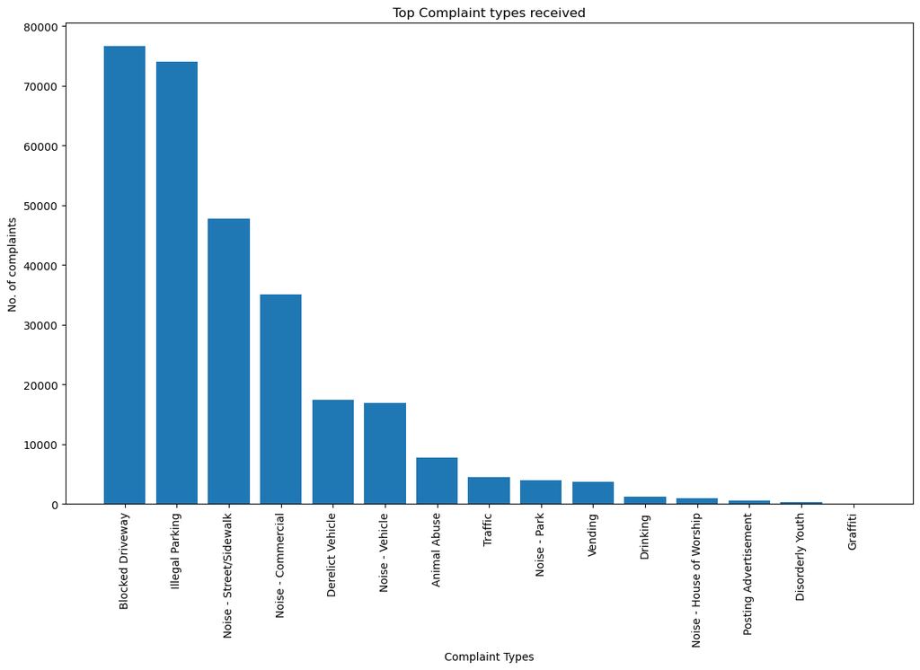

```python
complaint_counts = request_data['Complaint Type'].value_counts()
plt.figure(figsize = (14, 8))
plt.bar(complaint_counts.index, complaint_counts.values, width = 0.8)
plt.xticks(rotation=90)
plt.title("Top Complaint types received")
plt.xlabel('Complaint Types')
plt.ylabel('No. of complaints')
plt.show()
```

#### Complaints by Borough

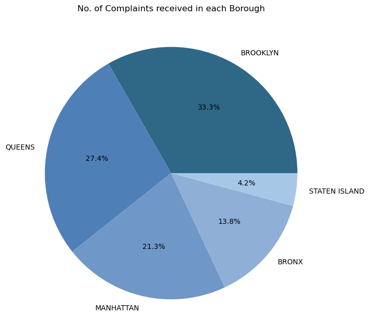

```python
complaint_borough = request_data['Borough'].value_counts()
plt.figure(figsize = (14, 8))
plt.pie(complaint_borough.values, labels=complaint_borough.index, autopct='%1.1f%%', colors=['#2F6787', '#4F7FB7', '#6F97C7', '#8FAFD7', '#A7C7E7'])
plt.title("No. of Complaints received in each Borough")
plt.show()
```

##### Borough with the highest no. of complaints

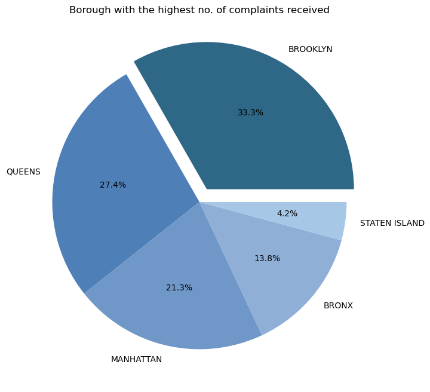

```python
plt.figure(figsize = (14, 8))
plt.pie(complaint_borough.values, labels=complaint_borough.index, autopct='%1.1f%%', colors=['#2F6787', '#4F7FB7', '#6F97C7', '#8FAFD7', '#A7C7E7'],
        explode = [0.1, 0, 0, 0, 0])
plt.title("Borough with the highest no. of complaints received")
plt.show()
```

##### Borough with the lowest no. of complaints

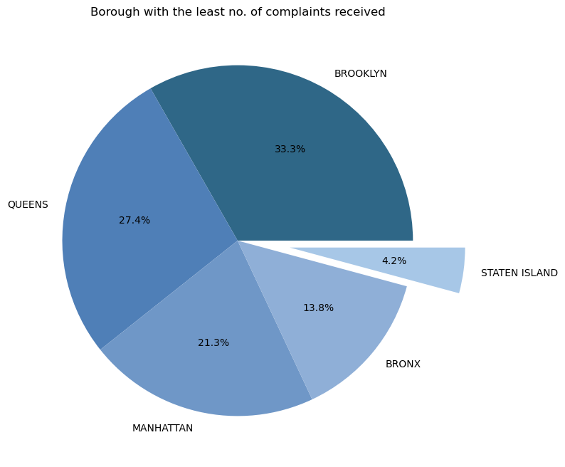

```python
plt.figure(figsize = (14, 8))
plt.pie(complaint_borough.values, labels=complaint_borough.index, autopct='%1.1f%%', colors=['#2F6787', '#4F7FB7', '#6F97C7', '#8FAFD7', '#A7C7E7'],
        explode = [0, 0, 0, 0, 0.3])
plt.title("Borough with the least no. of complaints received")
plt.show()
```

#### Complaint Trends in 2015 AD over months and weeks

##### Over Months

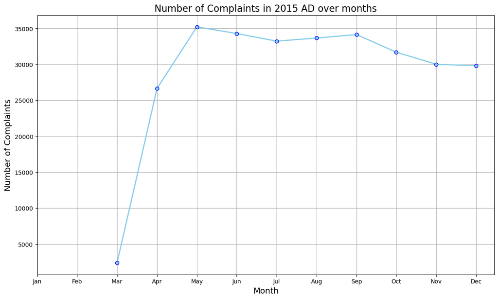

```python
complaint_dates_month = request_data['Created Date'].dt.month.value_counts().sort_index()

plt.figure(figsize=(14, 8))
plt.plot(complaint_dates_month.index, complaint_dates_month.values, marker = 'o', mfc = 'skyblue', mec = 'blue', color = 'skyblue', linewidth = 2)

plt.title('Number of Complaints in 2015 AD over months', fontsize = 16)
plt.xlabel('Month', fontsize = 14)
plt.ylabel('Number of Complaints', fontsize = 14)
plt.xticks(ticks = range(1, 13), labels = ['Jan', 'Feb', 'Mar', 'Apr', 'May', 'Jun', 'Jul', 'Aug', 'Sep', 'Oct', 'Nov', 'Dec'])
plt.grid(True)
plt.show()
```

##### Over Weeks

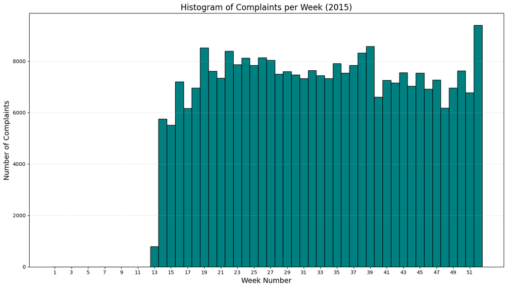

```python
weeks = request_data.loc[request_data['Created Date'].notna(), 'Created Date'].dt.isocalendar().week

plt.figure(figsize=(14, 8))
plt.hist(weeks, bins=range(1, 54), edgecolor='black', color='teal', align='left')

plt.title('Histogram of Complaints per Week (2015)', fontsize=16)
plt.xlabel('Week Number', fontsize=14)
plt.ylabel('Number of Complaints', fontsize=14)
plt.xticks(range(1, 53, 2))
plt.grid(axis='y', linestyle=':', alpha=0.7)

plt.tight_layout()
plt.show()
```

#### Average Response Time for each complaint types

##### Converting Request_Closing_Time into a numeric data in the dataframe

```python
request_data['Request_Closing_Time'] = request_data['Request_Closing_Time'].dt.total_seconds() / 3600
```

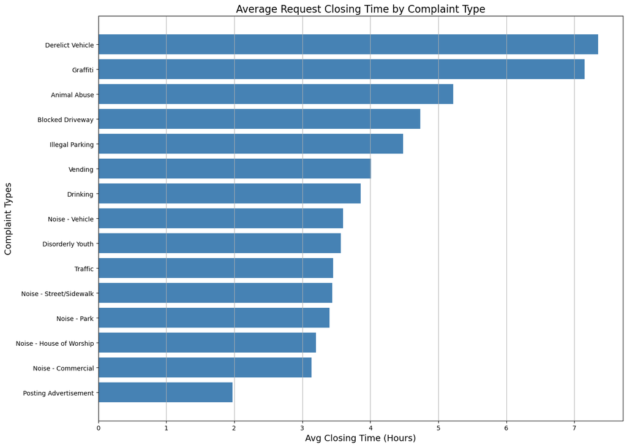

```python
avg_closing_time = request_data.groupby('Complaint Type')['Request_Closing_Time'].mean().sort_values(ascending=True)

plt.figure(figsize=(14, 10))
plt.barh(avg_closing_time.index, avg_closing_time.values, color='steelblue')
plt.title("Average Request Closing Time by Complaint Type", fontsize=16)
plt.xlabel('Avg Closing Time (Hours)', fontsize=14)
plt.ylabel('Complaint Types', fontsize=14)
plt.grid(True, axis='x')
plt.tight_layout()
plt.show()
```

#### Average Response Time of different complaint types in each Borough and Location Types

```python
avg_closing = request_data.groupby(['Borough', 'Complaint Type'])['Request_Closing_Time'].mean().reset_index()
```

##### Average Response time in boroughs for each complaint type

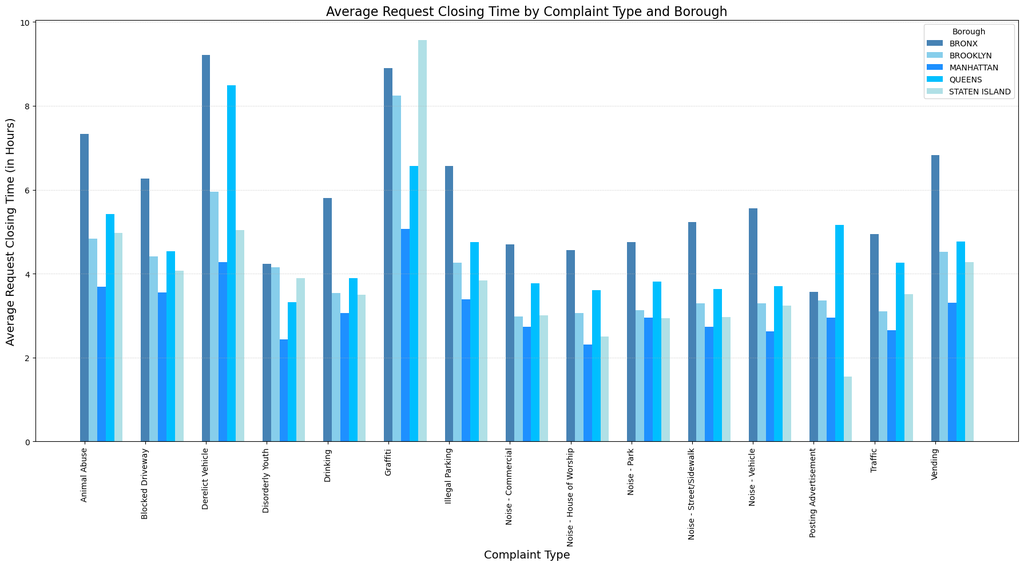

```python
pivot_complaint_type = avg_closing.pivot(index='Complaint Type', columns='Borough', values='Request_Closing_Time').fillna(0)

x = np.arange(len(pivot_complaint_type.index))
colors = ['steelblue', 'skyblue', 'dodgerblue', 'deepskyblue', 'powderblue']

plt.figure(figsize=(18, 10))
for index, borough in enumerate(pivot_complaint_type.columns):
    plt.bar(x + index * 0.14, pivot_complaint_type[borough], width = 0.14, label = borough, color = colors[index % len(colors)])

plt.xlabel('Complaint Type', fontsize = 14)
plt.ylabel('Average Request Closing Time (in Hours)', fontsize = 14)
plt.title('Average Request Closing Time by Complaint Type and Borough', fontsize = 16)
plt.xticks(ticks = range(0, 15), labels = pivot_complaint_type.index, rotation = 90)
plt.legend(title = 'Borough')
plt.grid(True, axis = 'y', linestyle = ':', alpha = 0.7)
plt.tight_layout()
plt.show()
```

##### Average Response time of complaint types in each borough

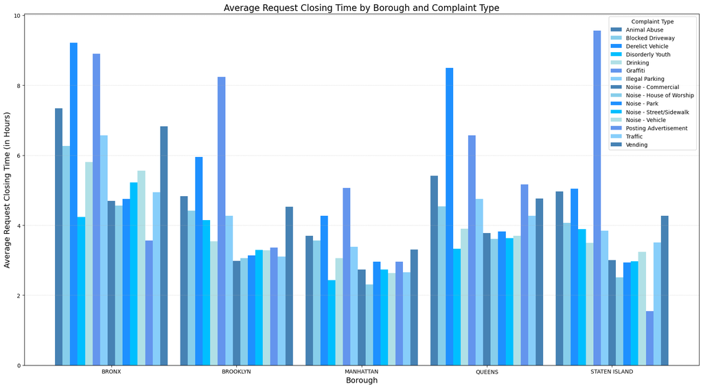

```python
pivot_borough = avg_closing.pivot(index='Borough', columns='Complaint Type', values='Request_Closing_Time').fillna(0)

boroughs = pivot_borough.index.tolist()
complaint_types = pivot_borough.columns.tolist()
x = np.arange(len(boroughs))
colors = ['steelblue', 'skyblue', 'dodgerblue', 'deepskyblue', 'powderblue', 'cornflowerblue', 'lightskyblue']

plt.figure(figsize=(18, 10))

for index, complaint in enumerate(complaint_types):
    plt.bar(x + index * 0.06, pivot_borough[complaint], width = 0.06, label = complaint, color = colors[index % len(colors)])

plt.xlabel('Borough', fontsize = 14)
plt.ylabel('Average Request Closing Time (in Hours)', fontsize = 14)
plt.title('Average Request Closing Time by Borough and Complaint Type', fontsize = 16)
plt.xticks(ticks = x + 0.06 * (len(complaint_types) - 1) / 2, labels = pivot_borough.index)
plt.legend(title = 'Complaint Type', loc='upper right')
plt.grid(True, axis = 'y', linestyle = ':', alpha = 0.7)
plt.tight_layout()
plt.show()
```

##### Heatmap for average response time of complaint types in various location types

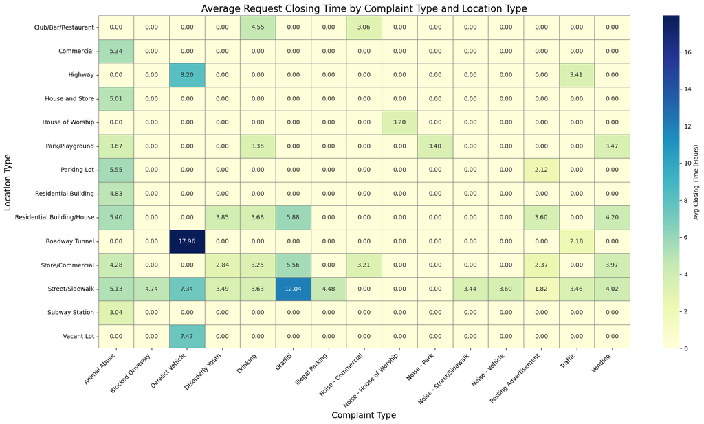

```python
import seaborn as sns

# Grouping and Pivot
avg = request_data.groupby(['Location Type', 'Complaint Type'])['Request_Closing_Time'].mean().reset_index()
pivot = avg.pivot(index='Location Type', columns='Complaint Type', values='Request_Closing_Time').fillna(0)

# Plotting with simpler styling
plt.figure(figsize=(18, 10))
sns.heatmap(
    pivot,
    annot=True, fmt='.2f', cmap='YlGnBu', cbar=True,  # Soft blue color palette
    annot_kws={"size": 10},  # Smaller annotation text
    linewidths=0.5, linecolor='gray',  # Thin gridlines for a cleaner look
    cbar_kws={"label": "Avg Closing Time (Hours)"},  # Color bar label
)

# Customize titles and labels
plt.title('Average Request Closing Time by Complaint Type and Location Type', fontsize=16)
plt.xlabel('Complaint Type', fontsize=14)
plt.ylabel('Location Type', fontsize=14)

# Rotate x-axis labels for better readability
plt.xticks(rotation=45, ha='right')

# Adjust layout
plt.tight_layout()
plt.show()
```

# Statistical Testing

### One way - ANOVA test to check whether the average response time across complaint types is similar or not

##### Importing f_oneway from scipy.stats

```python
from scipy.stats import f_oneway
```

#### Null Hypothesis, H0: Average request closing times, i.e. response times, are similar across the complaint types

```python
grouped_data = request_data.groupby('Complaint Type')['Request_Closing_Time'].apply(list)

f_stat, p_val = f_oneway(*grouped_data)

print(f"F-statistic: {f_stat}")
print(f"P-value: {p_val}")
if p_val < 0.05:
    print("Reject H0: At least one of the complaint types has a different average request closing time.")
else:
    print("Failed to reject H0: Average request closing times are similar across complaint types.")
```

```
F-statistic: 578.9120337398356
P-value: 0.0
Reject H0: At least one of the complaint types has a different average request closing time.
```

### Chi2 test to chek whether the type of complaint or service requested and location are related.

##### Importing chi2_contingency from scipy.stats

```python
from scipy.stats import chi2_contingency
```

#### Null Hypothesis, H0: Complaint Type and Location are not related

```python
contingency_table = pd.crosstab(request_data['Complaint Type'], request_data['Location Type'])


chi2, p, dof, expected = chi2_contingency(contingency_table)
print(f"p-value: {p}")
if p < 0.05:
    print("Reject H0: Complaint Type and Location Type are related.")
else:
    print("Failed to reject H0: Complaint Type and Location Type are not related.")
contingency_table
```

```
p-value: 0.0
Reject H0: Complaint Type and Location Type are related.
```

| Location Type Complaint Type | Club/Bar/Restaurant | Commercial | Highway | House and Store | House of Worship | Park/Playground | Parking Lot | Residential Building | Residential Building/House | Roadway Tunnel | Store/Commercial | Street/Sidewalk | Subway Station | Vacant Lot |
| --- | --- | --- | --- | --- | --- | --- | --- | --- | --- | --- | --- | --- | --- | --- |
| Animal Abuse | 0 | 62 | 0 | 93 | 0 | 120 | 109 | 226 | 5076 | 0 | 520 | 1516 | 22 | 0 |
| Blocked Driveway | 0 | 0 | 0 | 0 | 0 | 0 | 0 | 0 | 0 | 0 | 0 | 76676 | 0 | 0 |
| Derelict Vehicle | 0 | 0 | 13 | 0 | 0 | 0 | 0 | 0 | 0 | 5 | 0 | 17411 | 0 | 77 |
| Disorderly Youth | 0 | 0 | 0 | 0 | 0 | 0 | 0 | 0 | 77 | 0 | 8 | 200 | 0 | 0 |
| Drinking | 365 | 0 | 0 | 0 | 0 | 96 | 0 | 0 | 289 | 0 | 90 | 430 | 0 | 0 |
| Graffiti | 0 | 0 | 0 | 0 | 0 | 0 | 0 | 0 | 56 | 0 | 32 | 25 | 0 | 0 |
| Illegal Parking | 0 | 0 | 0 | 0 | 0 | 0 | 0 | 0 | 0 | 0 | 0 | 74021 | 0 | 0 |
| Noise - Commercial | 16807 | 0 | 0 | 0 | 0 | 0 | 0 | 0 | 0 | 0 | 18337 | 0 | 0 | 0 |
| Noise - House of Worship | 0 | 0 | 0 | 0 | 920 | 0 | 0 | 0 | 0 | 0 | 0 | 0 | 0 | 0 |
| Noise - Park | 0 | 0 | 0 | 0 | 0 | 3927 | 0 | 0 | 0 | 0 | 0 | 0 | 0 | 0 |
| Noise - Street/Sidewalk | 0 | 0 | 0 | 0 | 0 | 0 | 0 | 0 | 0 | 0 | 0 | 47747 | 0 | 0 |
| Noise - Vehicle | 0 | 0 | 0 | 0 | 0 | 0 | 0 | 0 | 0 | 0 | 0 | 16868 | 0 | 0 |
| Posting Advertisement | 0 | 0 | 0 | 0 | 0 | 0 | 7 | 0 | 54 | 0 | 6 | 580 | 0 | 0 |
| Traffic | 0 | 0 | 183 | 0 | 0 | 0 | 0 | 0 | 0 | 29 | 0 | 4254 | 0 | 0 |
| Vending | 0 | 0 | 0 | 0 | 0 | 103 | 0 | 0 | 201 | 0 | 432 | 3037 | 0 | 0 |